# Final Project

Data Science for Biologists, Spring 2021

Alexis Kulbacki

## Introduction

The ramen ratings dataset includes ramen data gathered by brand, variety, style, country, stars, and review number. I chose ramen ratings because it liked the variables within the dataset. The variables that sparked my interest are brand, country, variety, and style. These peeked my interest enabling critical thinking questions that I want to ask and find out from the dataset using graphs. [ramen dataset](https://github.com/rfordatascience/tidytuesday/tree/master/data/2019/2019-06-04)

```r
# reading in the data
ramen_ratings <- readr::read_csv("https://raw.githubusercontent.com/rfordatascience/tidytuesday/master/data/2019/2019-06-04/ramen_ratings.csv")

# view the data
glimpse(ramen_ratings)
```

```
## Rows: 3,180
## Columns: 6
## $ review_number <dbl> 3180, 3179, 3178, 3177, 3176, 3175, 3174, 3173, 3172, 31…
## $ brand         <chr> "Yum Yum", "Nagatanien", "Acecook", "Maison de Coree", "…
## $ variety       <chr> "Tem Tem Tom Yum Moo Deng", "tom Yum Kung Rice Vermicell…
## $ style         <chr> "Cup", "Pack", "Cup", "Cup", "Tray", "Cup", "Pack", "Pac…
## $ country       <chr> "Thailand", "Japan", "Japan", "France", "Japan", "Japan"…
## $ stars         <dbl> 3.75, 2.00, 2.50, 3.75, 5.00, 3.50, 3.75, 5.00, 3.50, 4.…
```

## Question 1

#### In Japan, what style of packaging is liked the least according to its total star rating?

### Methods

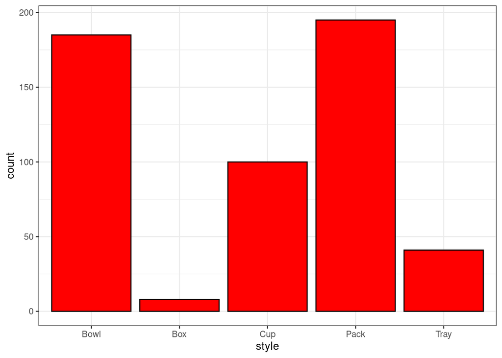

```r
# pipe in the data from ramen ratings dataset
ramen_ratings %>%
  # drop rows with no answer available for stars
   drop_na(stars) %>%
  # filter the country to be Japan
  filter(country == "Japan") %>%
  # select specific rows, in this case stars, country and style
  select(stars, country, style) %>%
  # ggplot function
  ggplot() +
  # places style on the x-axis
  aes(x = style) +
  # makes a histogram
  geom_histogram(stat = "count", color = "black",fill = "red") +
  # adds a light theme
  theme_bw()
```

## Question 2

#### In Japan, what is the distribtion of stars for bowl style ramen in the ramen ratings dataset?

### Methods

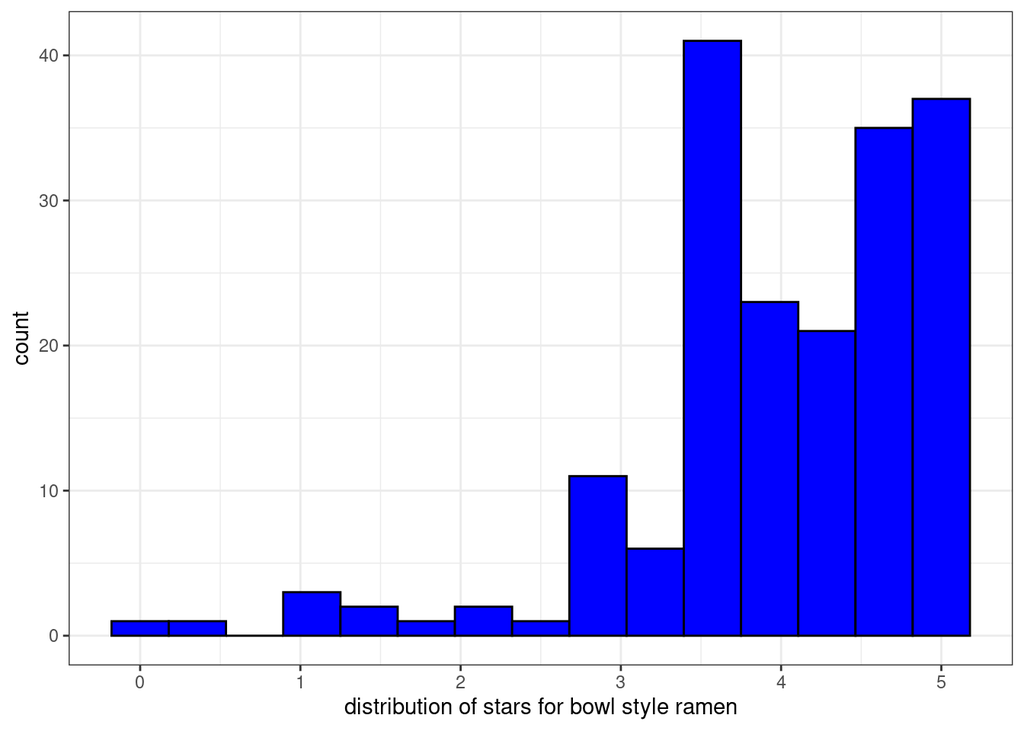

```r
# pipe in data from ramen ratings dataset
ramen_ratings %>%
  # filter country to be Japan and the style to be bowl
  filter(country == "Japan", style == "Bowl") %>%
  # keeps selected rows in this case, stars and style
  select(stars, style) %>%
  # ggplot function
  ggplot() +
  # adds stars on x-axis
  aes(x = stars) +
  # make a histogram and adds specific aesthetics that were selected in argument
  geom_histogram(bins = 15, color = "black", fill = "blue") +
  # adds label to x-axis to be distribution of stars for bowl style ramen
  labs(x= "distribution of stars for bowl style ramen") +
  # adds a black and white theme
  theme_bw()
```

## Question 3

#### What brands of ramen does Australia have?

### Methods

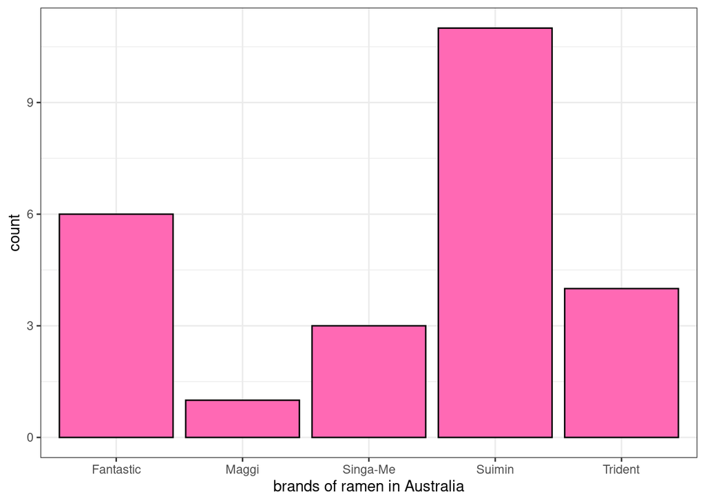

```r
# pipe in the data from ramen ratings dataset
ramen_ratings %>%
  # drops rows with no answers available for brand
  drop_na(brand) %>%
  # fitlers the country to be Australia
  filter(country == "Australia") %>%
  # selects just rows that are the brand
  select(brand) %>%
  # ggplot function
  ggplot() +
  # adds brand to be on x-axis
  aes(x = brand) +
  # make a bar graph and adds specific aesthestics that were selected in argument
  geom_bar(color = "black", fill = " hot pink") +
  # adds labels for the x-axis to be brand
  labs(x= "brands of ramen in Australia") +
  # adds a black and white theme
  theme_bw()
```

### Answer

The brands of ramen in Australia have are Fantastic, Maggi, Singa-Me, Suimin and Trident.

## Question 4

#### What is the distribution of stars for Myojo ramen in the ramen ratings dataset?

### Methods

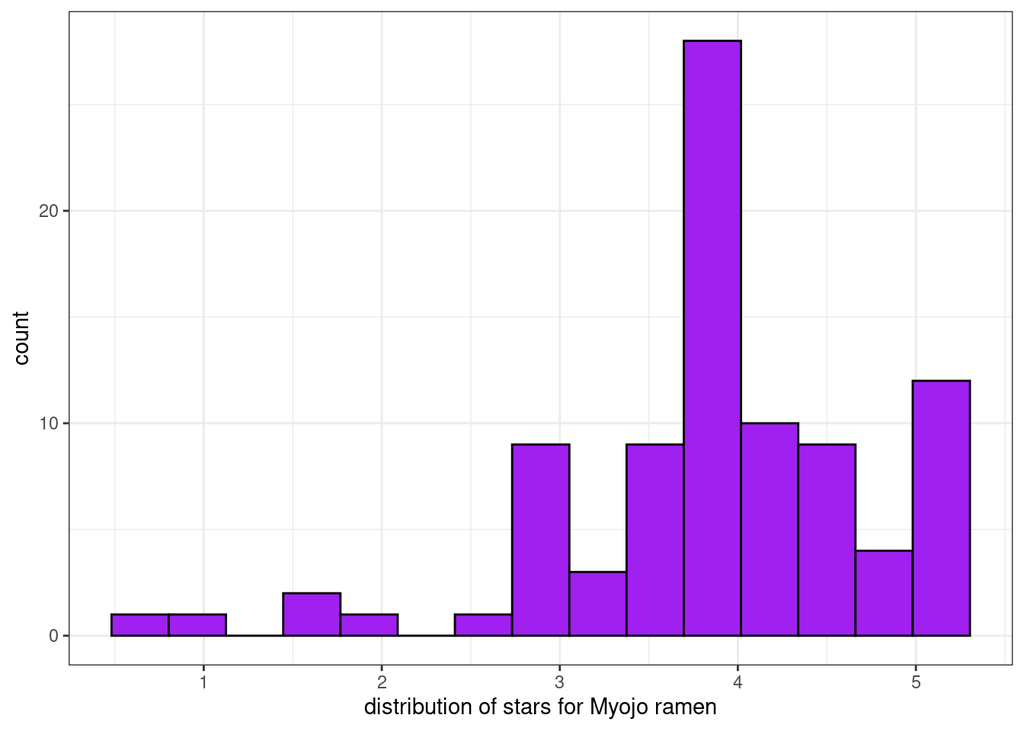

```r
  # pipe in data from ramen ratings dataset
  ramen_ratings %>%
  # filters brand to be Myojo ramen
  filter(brand == "Myojo") %>%
  # keeps rows only for stars
  select(stars) %>%
  # ggplot function
  ggplot() +
  # puts stars variable on x-axis
  aes(x = stars) +
  # makes a histogram and adds specific aesthetics that were selected in argument
  geom_histogram(bins = 15, color = "black", fill = "purple") +
  # adds label for a-axis to be stars for Myojo ramen
  labs(x= "distribution of stars for Myojo ramen") +
  # add black and white theme
  theme_bw()
```